# IPS et statut des lycées en Île-de-France - Une étude réalisée par Emma Vigneault, Simon Brigode et Tanguy Enez

2025-12-30

Cette étude emprunte d’autres outils statistiques construits par l’administration publique, notamment la valeur ajoutée (VA) des lycées. La VA mesure la performance d’un établissement scolaire en comparant les résultats obtenus par ses élèves à ceux attendus compte tenu de leur profil social et scolaire à l’entrée au lycée. Ainsi, un lycée avec une VA positive réussit mieux que prévu, tandis qu’une VA négative indique des performances inférieures aux attentes.

Nous avons choisi de centrer notre étude sur l’Ile-de-France. Etant l’une des régions les plus densément peuplées et relativement mixte d’un point de vue social, ce territoire nous paraissait pertinent pour une étude comparative portant sur l’IPS. Concernant le découpage géographique plus précis, nous avions au départ pensé construire nos groupes sur la base des académies. Cependant, ce découpage étant assez gros, nous avions peur de perdre de l’information, c’est pourquoi nous avons plutôt fait le choix de regrouper les données par départements (une variable département existant d’ailleurs dans l’annuaire des lycées de France).

# Présentation des résultats

Le code utilisé ci-dessus est déposé sur GitHub en open-source . Tous les résultats sont reproductibles et ont été rédigés sur Visual Studio Code (VSC).

#### Chargement des données

Le chargement des données a été réalisé à partir de plusieurs sources, notamment l’annuaire des lycées de France, les données IPS (de 2022) et valeur ajoutée. Les bases de données sont au format Parquet, un format de fichier optimisé pour le stockage et la lecture rapide de grandes quantités de données. Nous avons utilisé la bibliothèque `arrow` pour lire ces fichiers Parquet dans R.

Plusieurs jointures sont réalisées pour combiner les différentes sources de données. Nous effectuons une jointure interne (`inner_join`) entre l’annuaire des lycées et les données IPS, puis une autre jointure avec les données d’éloignement des lycées. Enfin, nous joignons les données de valeur ajoutée (IVAL) pour obtenir un ensemble de données complet.

Explorons maintenant les données combinées. Pour ce faire, nous allons nous intéresser aux lycées généraux et technologiques (GT) ainsi qu’aux lycées professionnels (PRO) d’Ile-de-France. Nous allons examiner la répartition des lycées selon leur statut (public ou privé) et analyser les différences d’IPS et de valeur ajoutée entre ces deux types d’établissements.

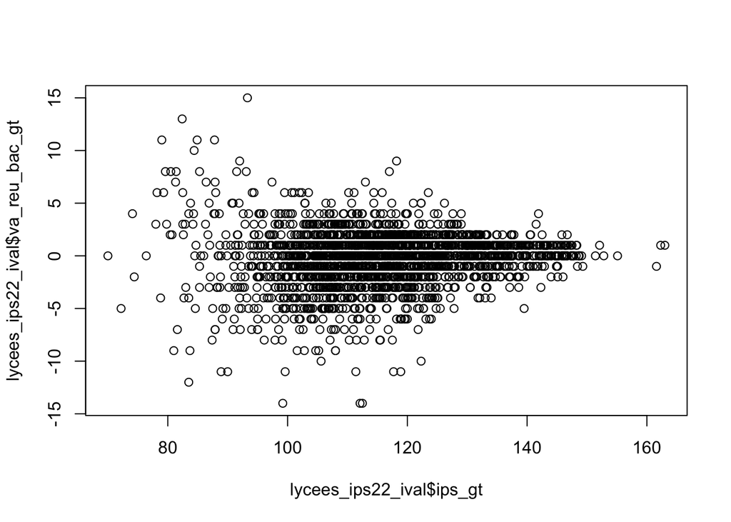

```r
plot(lycees_ips22_ival$ips_gt, lycees_ips22_ival$va_reu_bac_gt)
```

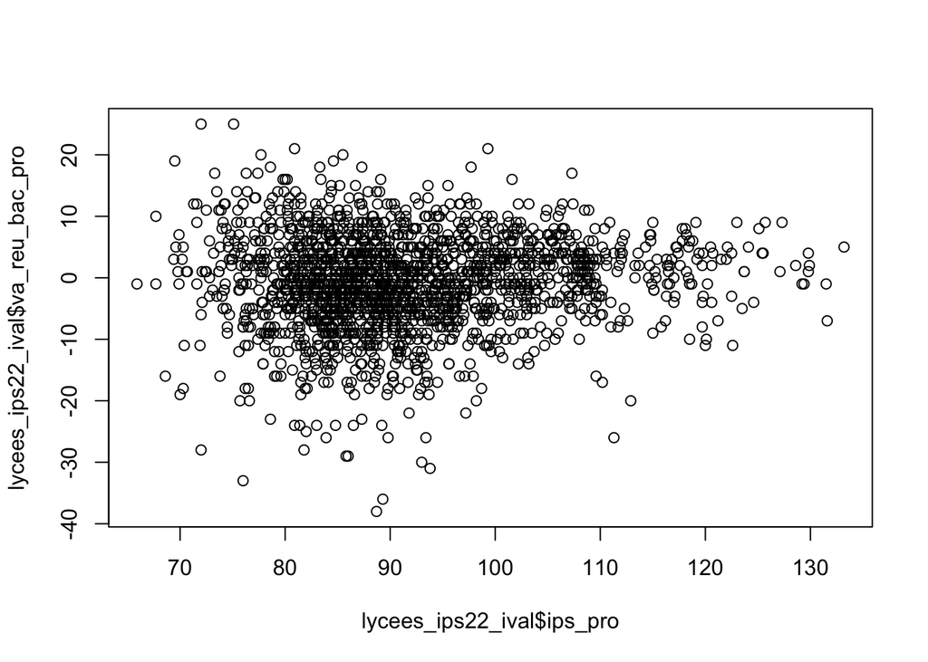

```r
plot(lycees_ips22_ival$ips_pro, lycees_ips22_ival$va_reu_bac_pro)
```

Les résultats révèlent que les lycées privés ont généralement un IPS plus élevé que les lycées publics, ce qui suggère une ségrégation sociale entre les deux types d’établissements. De plus, la valeur ajoutée des lycées privés tend à être supérieure à celle des lycées publics, indiquant que les établissements privés réussissent mieux que prévu compte tenu du profil social et scolaire de leurs élèves. La suite de cette étude vise à comprendre ce phénomène en profondeur.

## Lycées généraux et technologiques

Les lycées généraux et technologiques constituent une catégorie statistique importante pour analyser les dynamiques sociales au sein du système éducatif français. Depuis le décret n°85-1267 du 27 novembre 1985, les lycées généraux et techniques sont regroupés sous le nom de lycée d’enseignement général et technologique. Ces lycées constituent une catégorie qui s’oppose alors aux lycées professionnels, qui offrent une formation plus orientée vers les métiers manuels, moins socialement valorisés, tant d’un point de vue symbolique qu’économique. Cette étude se découpe alors en deux parties, l’une portant sur les lycées généraux et technologiques, l’autre sur les lycées professionnels.

Répartition des lycées généraux et technologiques en Île-de-France selon le statut

| Statut | Nombre de lycées | Pourcentage (%) |
| --- | --- | --- |
| Public | 323 | 66.7 |
| Privé | 161 | 33.3 |

Intéressons-nous d’abord aux `lycees_gt_idf` lycées généraux et technologiques d’Ile-de-France : 323 sont des établissements publics, quand 161 sont des établissements privés.

### Quelques statstiques descriptives

Statistiques descriptives – Lycées GT en Île-de-France (par statut)

| Statut | n | IPS (moy.) | IPS (méd.) | IPS (éc.-type) | IPS (min) | IPS (max) | Éloignement (méd.) | VA bac (moy.) | VA accès 2nde (moy.) | VA mention (moy.) |
| --- | --- | --- | --- | --- | --- | --- | --- | --- | --- | --- |
| Public | 323 | 111.9 | 111.1 | 18.2 | 76.4 | 161.6 | 96.8 | 0.0 | 3.2 | 1.8 |
| Privé | 161 | 135.3 | 137.5 | 11.4 | 101.2 | 162.3 | 96.5 | 1.1 | -0.6 | 5.5 |
| Privé – Public | NA | 23.4 | 26.4 | -6.8 | 24.8 | 0.7 | -0.3 | 1.1 | -3.8 | 3.7 |

### Tests de Wilcoxon - Comparaison Public / Privé

Afin d’approfondir l’analyse et de dépasser une approche strictement descriptive, nous avons complété ces comparaisons de distributions par une modélisation économétrique visant à identifier les déterminants de l’Indice de Position Sociale et de la valeur ajoutée des établissements.

Dans un premier temps, une régression linéaire de l’IPS sur le statut de l’établissement met en évidence un effet brut très marqué du secteur privé, traduisant une surreprésentation des élèves socialement favorisés dans ces établissements. Ce résultat confirme, dans un cadre paramétrique, les écarts observés précédemment à l’aide des tests non paramétriques.

L’introduction de l’indice d’éloignement comme variable de contrôle permet ensuite de tester l’hypothèse d’un effet territorial sur la composition sociale des lycées. Les estimations montrent que, toutes choses égales par ailleurs, l’effet du statut demeure élevé et statistiquement significatif, tandis que l’éloignement n’explique qu’une part marginale des variations de l’IPS. Ces résultats suggèrent que la ségrégation sociale entre établissements publics et privés ne relève pas principalement de contraintes géographiques, mais de mécanismes institutionnels et sociaux plus profonds.

Dans un second temps, la valeur ajoutée à la réussite au baccalauréat est modélisée conditionnellement à l’IPS, au statut de l’établissement et à l’éloignement. Les résultats indiquent qu’à caractéristiques sociales comparables, les établissements privés présentent un léger avantage en termes de valeur ajoutée. Toutefois, l’ampleur de cet effet reste limitée et son pouvoir explicatif demeure faible relativement à celui de la composition sociale des élèves.

Enfin, l’effet négatif de l’IPS sur la valeur ajoutée observé dans les estimations suggère que les établissements accueillant des élèves plus favorisés bénéficient mécaniquement de conditions de réussite initiales plus élevées, réduisant l’espace d’un « effet établissement » mesurable. Ce résultat s’inscrit dans la littérature classique sur la valeur ajoutée scolaire et souligne l’importance de distinguer performance brute et performance nette des caractéristiques sociales des élèves.

Tests de Wilcoxon – Comparaison Public / Privé (lycées GT, Île-de-France)

| Variable | Médiane_Public | Médiane_Prive | Privé – Public | p-value | Significativité |
| --- | --- | --- | --- | --- | --- |
| IPS (voie GT) | 111.1 | 137.5 | 26.4 | < 2e-16 | *** |
| Indice d’éloignement | 96.8 | 96.5 | -0.3 | 0.0533 |  |
| Valeur ajoutée – réussite au bac | 0.0 | 1.0 | 1.0 | 1.9e-09 | *** |

Test de Wilcoxon-Mann-Whitney. *** p<0.001, ** p<0.01, * p<0.05.

Afin de tester la robustesse des écarts observés entre lycées publics et privés, nous avons recours à des tests non paramétriques de Wilcoxon-Mann-Whitney, adaptés à la comparaison de distributions sans hypothèse de normalité ni d’homoscédasticité. Ce choix méthodologique se justifie à la fois par la nature asymétrique de certaines variables et par la présence de valeurs extrêmes susceptibles d’affecter les tests paramétriques classiques.

Les résultats mettent en évidence une différence très significative des distributions de l’Indice de Position Sociale entre établissements publics et privés. La médiane de l’IPS est sensiblement plus élevée dans le secteur privé, confirmant l’existence d’une forte ségrégation sociale entre les deux types d’établissements. Ce résultat ne porte pas uniquement sur une différence de moyennes, mais sur un décalage global des distributions, indiquant que la surreprésentation des élèves favorisés dans les lycées privés concerne l’ensemble de la distribution et non une fraction marginale des établissements.

À l’inverse, aucune différence statistiquement significative n’est observée concernant l’indice d’éloignement. Ce résultat suggère que les écarts de composition sociale entre lycées publics et privés ne s’expliquent pas principalement par des facteurs géographiques ou territoriaux, mais relèvent davantage de mécanismes institutionnels et sociaux, tels que les stratégies d’évitement de la carte scolaire ou les choix différenciés des familles selon leur capital social.

Enfin, la valeur ajoutée à la réussite au baccalauréat présente une différence statistiquement significative entre les deux secteurs, bien que d’ampleur plus limitée. Ce résultat indique que, si les établissements privés tendent à afficher une valeur ajoutée légèrement supérieure, cet avantage demeure modéré au regard de l’ampleur des écarts d’IPS. Il renforce ainsi l’idée que les différences de performance observées entre secteurs sont en grande partie liées à la composition sociale des élèves plutôt qu’à un effet pédagogique intrinsèque du statut de l’établissement.

Pris ensemble, ces tests non paramétriques confirment les résultats descriptifs et fournissent un cadre statistique robuste à l’analyse des inégalités sociales entre lycées publics et privés. Ils constituent une étape intermédiaire essentielle entre l’analyse descriptive et la modélisation économétrique, permettant de valider empiriquement l’existence d’écarts structurels avant d’en explorer les déterminants à l’aide de modèles multivariés.

### REPRESENTATION

Pour comparer la composition sociale des lycées publics et privés, nous représentons la distribution de l’Indice de Position Sociale au moyen d’un diagramme en boîte (« boîte à moustaches »). Ce graphique permet de synthétiser, pour chaque groupe, la médiane (trait au centre), l’étendue interquartile (la boîte, correspondant aux 50% des établissements les plus centraux), ainsi que les valeurs plus atypiques (moustaches et points isolés). Il est ainsi possible d’apprécier simultanément le niveau “typique” d’IPS dans chaque secteur et la dispersion interne des établissements.

Concrètement, un décalage des médianes indique une différence systématique entre secteurs (et non un écart porté par quelques cas isolés). La largeur de la boîte renseigne sur l’hétérogénéité : une boîte plus large signale une plus grande dispersion des IPS au sein du secteur considéré. Enfin, l’écart entre la médiane et la moyenne (point ◊) aide à repérer une éventuelle asymétrie de distribution : lorsque la moyenne s’éloigne de la médiane, cela suggère que certaines valeurs extrêmes “tirent” la distribution vers le haut ou vers le bas. Cette visualisation constitue ainsi une étape descriptive essentielle, en amont des tests d’inférence (Wilcoxon) et des modèles multivariés, pour documenter la structure des écarts public/privé.

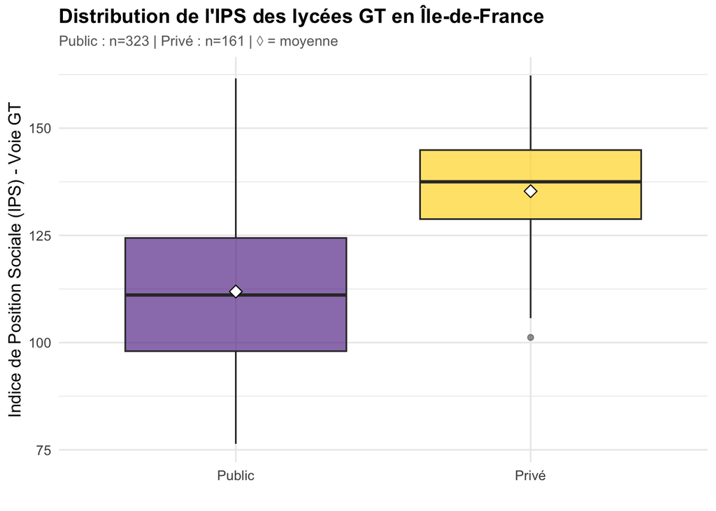

Les lycées généraux et technologiques privés, moins nombreux que les établissements publics, ont un IPS en moyenne plus élevé. La moyenne des lycées publics se situe presque parfaitement sur sa médiane, ce qui signifie que la distribution des IPS est relativement homogène et symétrique.

Cependant, bien que cet écart demeure assez faible, les établissements privés connaissent davantage d’inégalités puisque la moyenne des IPS se situe légèrement sous la médiane. La distribution des IPS dans les lycées privés est donc davantage resserrée que le public. Si cette distribution est presque aussi homogène que pour les lycées publics, une valeur est atypique : un lycée privé aurait un IPS, relativement faible par rapport aux autres (102).

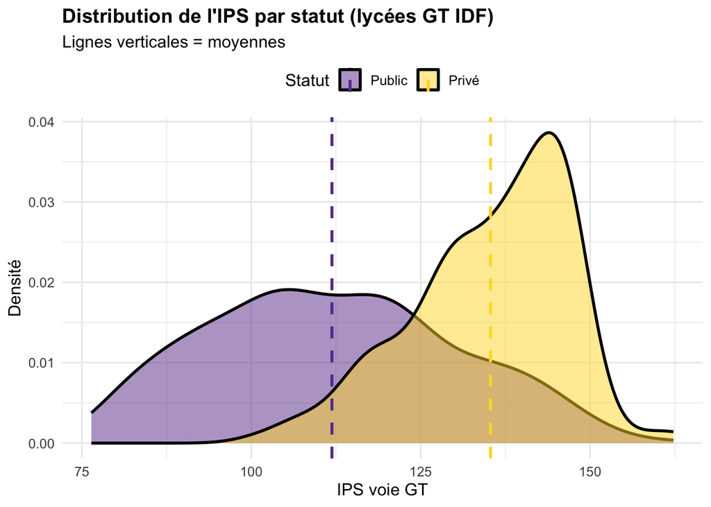

D’abord, la distribution complète de l’Indice de Position Sociale selon le statut de l’établissement. Le graphique de densité permet d’appréhender simultanément la position, la dispersion et la forme des distributions, tout en limitant la sensibilité aux valeurs extrêmes. Il apparaît nettement que la distribution des IPS des lycées privés est décalée vers la droite par rapport à celle des lycées publics, traduisant une concentration plus forte d’établissements accueillant des élèves socialement favorisés. Les lignes verticales représentant les moyennes confirment cet écart structurel, déjà mis en évidence par les statistiques descriptives et les tests non paramétriques. Ce résultat suggère que la différenciation public/privé ne relève pas seulement de quelques établissements atypiques, mais d’un phénomène de structuration globale des populations scolaires.

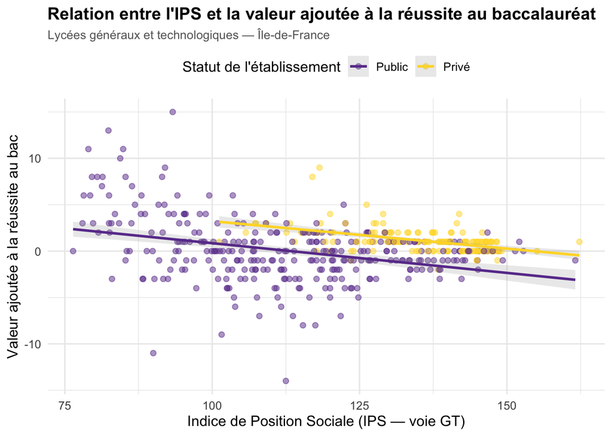

Ensuite, la relation entre la composition sociale des établissements, mesurée par l’IPS, et leur valeur ajoutée à la réussite au baccalauréat. Le nuage de points permet d’observer la dispersion des établissements, tandis que les droites de régression linéaire, estimées séparément par statut, fournissent une première approximation des tendances moyennes. On observe une relation globalement négative entre l’IPS et la valeur ajoutée, suggérant que les établissements accueillant des élèves plus favorisés disposent, en moyenne, d’une marge de progression plus limitée en termes de performance relative. Cette dynamique est cohérente avec la logique même de la valeur ajoutée, conçue pour neutraliser les effets de la composition sociale. Par ailleurs, les différences de pente et de niveau entre établissements publics et privés restent modestes, ce qui indique que l’avantage apparent du privé en matière de résultats bruts s’atténue fortement une fois prise en compte la structure sociale des élèves.

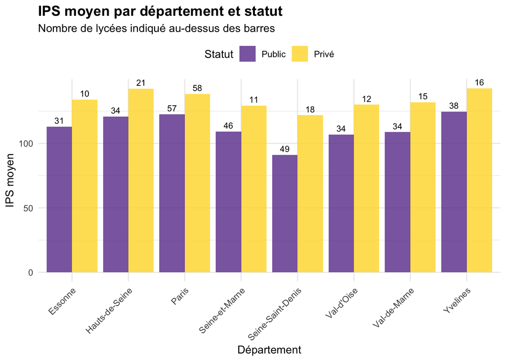

Enfin, l’analyse par département permet d’introduire une dimension territoriale à l’étude des inégalités sociales entre établissements. En représentant l’IPS moyen par département et par statut, nous cherchons à identifier d’éventuelles hétérogénéités spatiales dans l’ampleur des écarts public/privé.

De plus, cet écart d’IPS se cumule avec des inégalités de répartition des lycées généraux et technologiques selon leur statut. En effet, le statut du lycée ne semble avoir que très peu d’effet sur l’IPS moyen ; on compte cependant presque le même nombre de lycées publics que privés. Le moindre effet du statut de l’établissement sur l’IPS pourrait donc s’expliquer par la quasi parfaite distribution des élèves entre les lycées publics et privés. On pourrait également ajouter à cela le fait qu’à Paris, les élèves ne sont pas attribués d’office à un lycée public mais doivent postuler à plusieurs établissements.Les élèves issus des milieux les plus favorisés (ayant donc un IPS plus élevé) se détourneraient davantage des établissements privés. En effet, ceux-ci sont en règle générale plutôt utilisés par les familles les plus aisées pour contourner la carte scolaire (Merle, 2012).

Les “bonnes familles” candidateraient donc d’abord aux “bons lycées” publics. Au contraire, pour les familles appartenant à des classes moins favorisées, inscrire leur enfant dans un établissement privé pourrait constituer un moyen d’éviter de se retrouver dans un lycée public moins côté. Ainsi, tous ces mécanismes conduisent à une convergence mathématique des IPS moyens entre les lycées généraux et technologiques privés et publics. Notons que pour le cas de Paris, une analyse en termes d’arrondissements aurait pu s’avérer pertinente pour compléter plus finement notre analyse. Pour les autres départements, la surreprésentation des élèves possédant un fort IPS dans les lycées privés (malgré le faible nombre de ces établissements) s’explique donc principalement par des stratégies de contournement de la carte scolaire (Merle, 2012).

# Régressions linéaires : facteurs explicatifs

Le recours à des régressions linéaires permet de dépasser une lecture exclusivement descriptive des écarts observés entre lycées publics et privés. Si les statistiques descriptives, les visualisations et les tests non paramétriques mettent en évidence des différences nettes de composition sociale et de performance scolaire, ils ne permettent pas d’évaluer simultanément l’influence relative de plusieurs facteurs. Les modèles estimés visent ainsi à structurer l’analyse en distinguant l’effet associé au statut institutionnel de l’établissement de celui lié à la composition sociale des élèves et aux caractéristiques territoriales. Dans cette perspective, l’économétrie ne constitue pas un outil d’identification causale, mais un cadre analytique permettant de hiérarchiser les déterminants des écarts observés et de tester la robustesse des résultats descriptifs.

Régressions linéaires (lycées GT, Île-de-France) — coefficients (hors constante)

| Modèle | Variable | Coef. | Écart-type | t | p-value |
| --- | --- | --- | --- | --- | --- |
| M1 : IPS ~ statut | statutPrivé | 23.393 | 1.568 | 14.92 | < 2e-16 |
| M2 : IPS ~ statut + log(éloignement) | statutPrivé | 23.587 | 1.575 | 14.98 | < 2e-16 |
| M2 : IPS ~ statut + log(éloignement) | log_elgnmt | 34.059 | 27.479 | 1.24 | 0.21578 |
| M3 : VA bac ~ IPS + statut + log(éloignement) | ips_gt | -0.062 | 0.008 | -7.96 | 1.40e-14 |
| M3 : VA bac ~ IPS + statut + log(éloignement) | statutPrivé | 2.417 | 0.322 | 7.51 | 3.23e-13 |
| M3 : VA bac ~ IPS + statut + log(éloignement) | log_elgnmt | -14.271 | 4.638 | -3.08 | 0.00222 |

Ces régressions servent à compléter l’analyse descriptive et non paramétrique des écarts observés entre lycées publics et privés, nous avons mobilisé une série de régressions linéaires visant à structurer l’interprétation des différences de composition sociale et de performance scolaire. L’objectif n’est pas d’identifier un effet causal strict du statut de l’établissement, mais de quantifier et de comparer, dans un cadre paramétrique, les associations observées entre statut institutionnel, caractéristiques territoriales et indicateurs scolaires.

La première régression linéaire de l’Indice de Position Sociale moyen des établissements sur le seul statut public ou privé. Ce premier modèle permet de mesurer l’écart brut de composition sociale entre les deux types d’établissements. Les résultats mettent en évidence un différentiel très marqué en faveur des lycées privés, traduisant une surreprésentation des élèves issus de milieux socialement favorisés dans ces établissements. La part importante de la variance de l’IPS expliquée par le statut confirme, dans un cadre paramétrique, l’existence d’une ségrégation sociale structurée entre les secteurs public et privé, déjà observée à travers les statistiques descriptives et les tests de comparaison de distributions.

La seconde régression linéaire introduit l’indice d’éloignement des lycées afin de contrôler les effets liés à la localisation géographique et à l’accessibilité territoriale des établissements. Cet indicateur, construit par l’administration, prend en compte le lieu de résidence des élèves, la densité de l’offre scolaire et la présence d’équipements à proximité. L’objectif est de tester l’hypothèse selon laquelle une partie des écarts d’IPS pourrait s’expliquer par des contraintes territoriales plutôt que par le statut institutionnel lui-même. Les estimations montrent que, toutes choses égales par ailleurs, l’effet du statut demeure élevé et statistiquement significatif, tandis que l’éloignement n’explique qu’une part marginale des variations de l’IPS. Ces résultats suggèrent que la différenciation sociale entre lycées publics et privés ne relève pas principalement de la géographie, mais de mécanismes sociaux et institutionnels plus profonds, tels que les stratégies de choix des familles ou les modalités de régulation de l’accès aux établissements.

La troisième régression déplace l’analyse vers la performance scolaire, mesurée par la valeur ajoutée à la réussite au baccalauréat. La valeur ajoutée est ici modélisée en fonction de l’IPS moyen de l’établissement, du statut public ou privé et de l’indice d’éloignement. Ce modèle vise à distinguer ce qui relève de la composition sociale des élèves de ce qui pourrait correspondre à un effet propre de l’établissement. Les résultats indiquent qu’à caractéristiques sociales et territoriales comparables, les lycées privés présentent en moyenne une valeur ajoutée légèrement supérieure à celle des lycées publics. Toutefois, l’ampleur de cet effet reste limitée et son pouvoir explicatif demeure modeste par rapport à celui de la composition sociale.

Par ailleurs, l’effet négatif de l’IPS sur la valeur ajoutée observé dans les estimations suggère que les établissements accueillant des élèves socialement favorisés disposent mécaniquement de moins de marges pour produire une valeur ajoutée élevée, les probabilités de réussite étant déjà importantes en amont. Ce résultat s’inscrit dans la littérature classique sur l’évaluation des performances scolaires et souligne l’importance de distinguer la réussite brute des élèves de la performance nette des établissements. Dans l’ensemble, ces modèles confirment que la composition sociale constitue le déterminant central des écarts observés, tandis que l’« effet établissement », bien que réel, apparaît quantitativement secondaire.

# Lycées professionnels

**Données disponibles (lycées professionnels, Île-de-France)** — N = 322.

Répartition des lycées professionnels par statut

| Statut | n | Part (%) |
| --- | --- | --- |
| Public | 274 | 85.1 |
| Privé | 48 | 14.9 |

L”analyse porte sur 322 lycées professionnels situés en Île-de-France disposant d’un IPS valide pour la voie professionnelle. La très grande majorité de ces établissements relève du secteur public, qui concentre 274 lycées, soit 85,1 % de l”échantillon. À l’inverse, le secteur privé apparaît nettement plus marginal dans l’enseignement professionnel, avec 48 établissements, représentant 14,9 % du total.

Cette forte asymétrie institutionnelle distingue nettement la filière professionnelle de la filière générale et technologique, au sein de laquelle le secteur privé occupe une place plus importante. Elle suggère que les mécanismes de concurrence entre établissements et les stratégies de contournement de la carte scolaire jouent un rôle plus limité dans la voie professionnelle, largement structurée par l’offre publique. Cette configuration spécifique invite à analyser avec prudence les écarts d’IPS entre établissements publics et privés.

### Statistiques générales des lycées professionnels

À partir des données disponibles sur les lycées professionnels d’Île-de-France (N = 322), l’échantillon met d’abord en évidence un déséquilibre marqué des effectifs entre secteurs : 274 établissements publics (85,1 %) contre 48 établissements privés (14,9 %). Cette asymétrie n’est pas qu’un détail descriptif : elle rappelle que les comparaisons entre statuts portent sur des populations de taille différente, et qu’il est donc utile de mobiliser des indicateurs robustes (médianes, tests non paramétriques) en complément des seules moyennes.

L’objectif de cette section est double. D’une part, documenter la structure sociale des lycées professionnels via l’IPS (voie pro) et vérifier si l’écart public/privé relève d’un simple effet de quelques établissements atypiques ou d’un phénomène plus général. D’autre part, replacer cette opposition dans un cadre plus large, en regardant si des dimensions souvent invoquées — comme l’éloignement — ou des indicateurs de performance « nette » — comme la valeur ajoutée — se différencient également entre secteurs.

Statistiques descriptives (lycées professionnels, Île-de-France) — par statut

| Statut | N | IPS moy. | IPS méd. | IPS sd | IPS min | IPS max | Éloignement méd. | VA bac moy. | VA 2nde moy. | VA mentions moy. |
| --- | --- | --- | --- | --- | --- | --- | --- | --- | --- | --- |
| Public | 274 | 88.1 | 87.3 | 7.7 | 72.5 | 122.6 | 97.0 | 1.0 | 3.2 | 3.4 |
| Privé | 48 | 118.6 | 119.6 | 8.8 | 96.2 | 133.2 | 96.2 | 2.7 | 2.2 | 5.4 |
| Écart (Privé − Public) | NA | 30.5 | NA | NA | NA | NA | NA | NA | NA | NA |

Ces statistiques générales indiquent une fracture sociale très nette : l’IPS moyen atteint 88,1 dans le public contre 118,6 dans le privé, soit un écart d’environ 30,5 points. Cette différence est confirmée par les médianes (87,3 vs 119,6), ce qui suggère qu’on n’est pas face à un artefact lié à quelques valeurs extrêmes mais bien à un décalage systématique de la distribution. Les bornes observées renforcent ce constat : les établissements privés se situent globalement à des niveaux d’IPS plus élevés (minimum privé à 96,2, quand le public descend à 72,5).

Le test de Wilcoxon-Mann-Whitney consolide l’argument en s’affranchissant des hypothèses de normalité : l’écart d’IPS (voie pro) entre statuts est hautement significatif (p < 2e-16), avec un différentiel médian de +32,2 points en faveur du privé. En clair, dans la voie professionnelle, le privé apparaît comme un espace de scolarisation socialement bien plus favorisé que le public, ce qui correspond à une forme de segmentation sociale particulièrement marquée.

En complément, l’indicateur d’éloignement introduit une dimension plus territoriale. Le test de Wilcoxon indique un écart statistiquement significatif (p = 0,0011) mais faible en magnitude : la médiane est de 97,0 pour le public contre 96,2 pour le privé (différence de -0,8). Autrement dit, la significativité tient surtout à la taille d’échantillon et à la stabilité des distributions ; en pratique, l’éloignement ne semble pas constituer un mécanisme central capable d’expliquer à lui seul l’ampleur des écarts d’IPS observés.

C’est exactement ce que suggèrent les résultats : malgré une médiane de valeur ajoutée légèrement plus élevée dans le privé (3,0 contre 2,0, soit +1), le test de Wilcoxon indique que la différence n’est pas statistiquement significative (p = 0,2737). Autrement dit, les écarts de valeur ajoutée à la réussite au bac pro ne permettent pas, à ce stade, de conclure à une supériorité systématique d’un secteur sur l’autre. Dans le cadre de l’analyse IPS, c’est une information importante : le clivage le plus robuste se situe du côté de la composition sociale, davantage que du côté de la performance ajoutée.

Tests de Wilcoxon — comparaison public / privé (lycées professionnels, Île-de-France)

[output not shown]

Pris ensemble, ces résultats décrivent une voie professionnelle francilienne très fortement structurée par le statut public/privé du point de vue de l’IPS. L’écart d’environ 30 points (moyenne et médiane) et sa significativité extrême suggèrent que le privé professionnel ne scolarise pas « le même public » que le public : il accueille, en moyenne, des élèves bien plus favorisés socialement. Cette configuration renvoie à des mécanismes de sélection et d’orientation (choix des familles, contraintes de coût, stratégies d’évitement, offre de formations), qui dépassent largement une simple logique géographique.

En revanche, l’éloignement ne joue qu’un rôle marginal (différence faible malgré une significativité statistique) et la valeur ajoutée au bac pro ne diffère pas de façon robuste entre secteurs. Autrement dit, la séparation public/privé apparaît d’abord comme une différenciation sociale, pas comme une hiérarchie nette de « performance ajoutée » mesurée. La suite logique, si vous voulez renforcer l’argument de façon économétrique, est de tester si l’effet “privé” sur la valeur ajoutée subsiste conditionnellement à l’IPS (et à l’éloignement), afin de distinguer ce qui relève de la composition sociale de ce qui relèverait d’un éventuel effet établissement.

### Visualisations des lycées professionnels

cette section se concentre sur les lycées professionnels en Île-de-France. L’objectif est d’examiner si les clivages sociaux observés précédemment selon le statut de l’établissement (public/privé) se retrouvent, et éventuellement s’amplifient, dans l’enseignement professionnel, historiquement associé à des trajectoires scolaires et sociales plus différenciées. Les visualisations suivantes permettent d’appréhender successivement la distribution de l’IPS, sa relation avec la valeur ajoutée à la réussite au baccalauréat, ainsi que ses variations territoriales

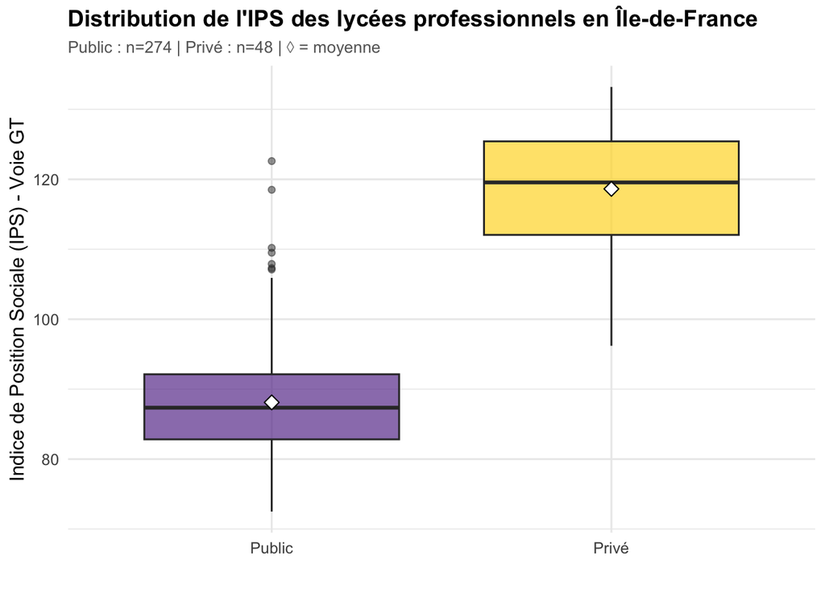

Cette représentation visuelle sous forme de “boîte à moustache” permet de constater que les écarts d’IPS entre les lycées professionnels publics et privés sont plus importants que pour les lycées généraux et technologiques.

L’enseignement professionnel est très clivé socialement selon le type d’établissement.En effet, alors que l’IPS moyen des lycées publics est d’environ 88 (ce qui correspond aux classes les moins favorisées), celui des lycées privés s’élève à 118.Ce clivage est tellement extrême qu’on pourrait ici parler de ségrégation, puisque les deux boîtes ne se chevauchent quasiment pas, les valeurs extrêmes - maximales - pour les lycées publics étant égales aux basses observations pour les lycées privés. Pour expliquer ces différences, il pourrait être intéressant d’étudier les filières professionnelles (hôtellerie, BTP, mécanique, artisanat de luxe…) pour constater si elles sont différenciées socialement, et donc, in fine, si ces filières sont réparties inégalement selon le type d’établissement (privé ou public). Cependant, s’il existe un clivage entre les établissements publics et privés, chaque groupe semble relativement homogène en son sein, les boîtes les représentant étant assez petites.

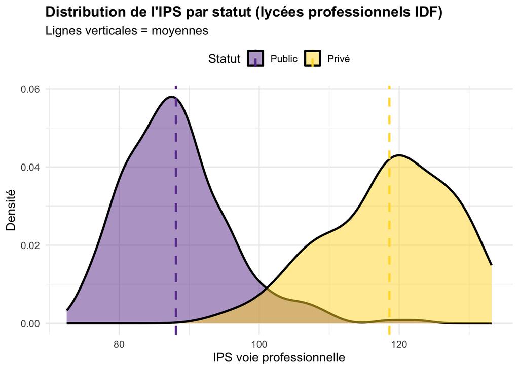

L’analyse des distributions de densité confirme et précise les enseignements tirés du boxplot. Les courbes associées aux lycées publics et privés apparaissent nettement distinctes, avec des moyennes (indiquées par les lignes verticales) très éloignées l’une de l’autre.

La distribution des lycées publics se concentre autour de niveaux d’IPS faibles à intermédiaires, tandis que celle des établissements privés est déplacée vers des niveaux nettement plus élevés. Le faible chevauchement des densités suggère que la différenciation sociale ne relève pas seulement de quelques établissements atypiques, mais correspond à une structuration globale du secteur professionnel. Ces résultats sont cohérents avec l’idée d’une orientation socialement différenciée vers les filières professionnelles, renforcée par des mécanismes de sélection propres au secteur privé.

[figure not shown]

Le graphique croisant l’IPS et la valeur ajoutée à la réussite au baccalauréat permet d’interroger le lien entre composition sociale des établissements et performance éducative. Une relation globalement négative entre l’IPS et la valeur ajoutée apparaît, en particulier pour les lycées publics, suggérant que les établissements accueillant les élèves les plus favorisés disposent mécaniquement d’un moindre « potentiel » de valeur ajoutée mesurable.

Les établissements privés se distinguent par des niveaux d’IPS plus élevés, mais ne présentent pas nécessairement une valeur ajoutée significativement supérieure. Cette observation rejoint les résultats des tests statistiques, qui indiquent l’absence de différence significative de valeur ajoutée entre public et privé dans l’enseignement professionnel. Elle invite à distinguer clairement la réussite brute des élèves et l’effet propre de l’établissement, en particulier dans des contextes où les trajectoires scolaires sont fortement socialement déterminées.

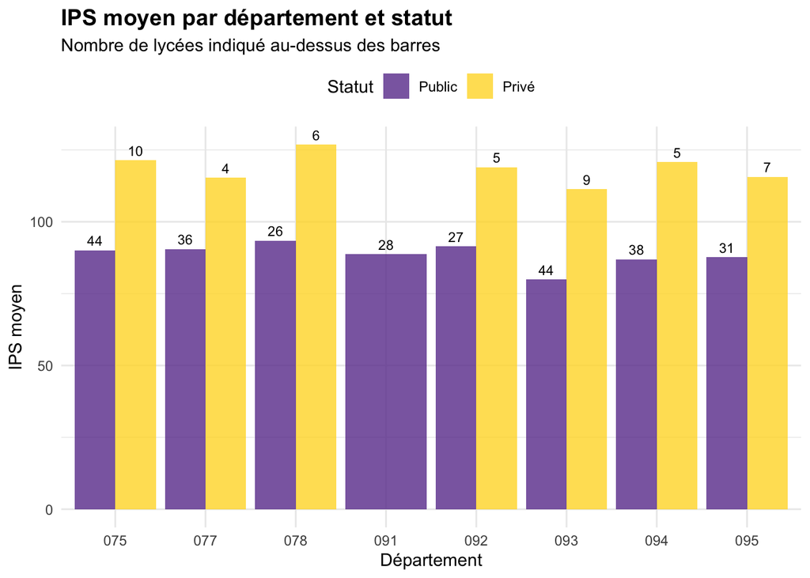

### Analyses économétriques sur les lycées professionnels

Cette section teste formellement les relations mises en évidence précédemment, en mobilisant une série de régressions linéaires appliquées aux lycées professionnels d’Île-de-France. L’objectif est double. Il s’agit, d’une part, d’évaluer dans quelle mesure les écarts d’IPS observés entre établissements publics et privés persistent une fois introduits des facteurs de contrôle, et, d’autre part, d’examiner la relation entre composition sociale des élèves et performance scolaire mesurée par la valeur ajoutée à la réussite au baccalauréat. Cette démarche permet de dépasser une simple comparaison de moyennes et d’inscrire l’analyse dans un cadre explicatif, tout en conservant une lecture prudente des résultats.

Régressions linéaires (lycées professionnels, Île-de-France) — coefficients (hors constante)

| Modèle | Variable | Coef. | Écart-type | t | p-value |
| --- | --- | --- | --- | --- | --- |
| M1 : IPS ~ statut | statutPrivé | 30.524 | 1.224 | 24.93 | < 2e-16 |
| M2 : IPS ~ statut + log(éloignement) | statutPrivé | 31.259 | 1.221 | 25.61 | < 2e-16 |
| M2 : IPS ~ statut + log(éloignement) | log_elgnmt | 59.259 | 16.746 | 3.54 | 0.000462 |
| M3 : VA bac ~ IPS + statut + log(éloignement) | ips_pro | -0.230 | 0.059 | -3.90 | 0.000119 |
| M3 : VA bac ~ IPS + statut + log(éloignement) | statutPrivé | 7.935 | 2.266 | 3.50 | 0.000530 |
| M3 : VA bac ~ IPS + statut + log(éloignement) | log_elgnmt | -63.721 | 17.982 | -3.54 | 0.000455 |

Statistiques de synthèse des modèles (lycées professionnels, Île-de-France)

| Modèle | N | R2 | R2_adj |
| --- | --- | --- | --- |
| M1 : IPS ~ statut | 322 | 0.660 | 0.659 |
| M2 : IPS ~ statut + log(éloignement) | 322 | 0.673 | 0.671 |
| M3 : VA bac ~ IPS + statut + log(éloignement) | 319 | 0.103 | 0.094 |

Le premier modèle estime l’effet brut du statut de l’établissement sur l’IPS des lycées professionnels. Les résultats mettent en évidence un écart très marqué entre les établissements publics et privés. À caractéristiques non contrôlées, les lycées professionnels privés présentent un IPS moyen supérieur d’environ trente points à celui des lycées publics. Le pouvoir explicatif de ce modèle est particulièrement élevé, ce qui indique que le statut de l’établissement constitue un facteur central de différenciation sociale dans l’enseignement professionnel. Ce résultat confirme et formalise les constats issus de l’analyse descriptive, selon lesquels l’enseignement professionnel privé accueille une population d’élèves socialement beaucoup plus favorisée.

Le second modèle introduit l’indice d’éloignement comme variable de contrôle afin de tenir compte de la dimension territoriale et de l’accessibilité des établissements. L’ajout de cette variable modifie très marginalement l’estimation de l’effet du statut : à éloignement constant, l’écart d’IPS entre lycées professionnels publics et privés demeure d’un ordre de grandeur similaire. L’indice d’éloignement apparaît statistiquement significatif, mais son effet reste secondaire relativement à celui du statut. Autrement dit, les différences de composition sociale observées entre établissements ne semblent pas principalement imputables à des contraintes géographiques ou d’accessibilité, mais relèvent avant tout de mécanismes de sélection sociale liés au fonctionnement même du secteur public et du secteur privé dans l’enseignement professionnel.

Le troisième modèle s’intéresse à la valeur ajoutée à la réussite au baccalauréat professionnel, conditionnellement à l’IPS, au statut de l’établissement et à l’éloignement. Les estimations indiquent, d’une part, une relation négative entre l’IPS et la valeur ajoutée : toutes choses égales par ailleurs, les établissements accueillant des élèves socialement plus favorisés tendent à présenter une valeur ajoutée plus faible. Ce résultat est cohérent avec l’interprétation même de l’indicateur de valeur ajoutée, qui vise précisément à neutraliser les avantages initiaux liés à la composition sociale des élèves.

D’autre part, à IPS et éloignement comparables, les lycées professionnels privés présentent une valeur ajoutée légèrement supérieure à celle des lycées publics. Cet effet demeure toutefois d’ampleur modérée et s’accompagne d’un pouvoir explicatif global relativement limité du modèle. Ces résultats suggèrent l’existence d’un différentiel de performance nette en faveur du secteur privé, sans pour autant permettre de conclure à un effet massif ou dominant du statut de l’établissement sur les résultats scolaires, une fois prises en compte les caractéristiques sociales des élèves.

L’analyse économétrique des lycées professionnels met en évidence une ségrégation sociale particulièrement forte entre établissements publics et privés, bien plus marquée que dans l’enseignement général et technologique. Le statut de l’établissement apparaît comme un déterminant majeur de l’IPS, y compris après contrôle de l’éloignement géographique. En revanche, lorsque l’on s’intéresse à la performance scolaire mesurée par la valeur ajoutée, les écarts entre secteurs se révèlent plus limités et doivent être interprétés avec prudence. Ces résultats confirment l’importance de distinguer la composition sociale des établissements de leur performance propre, et soulignent le rôle central des mécanismes de sélection sociale dans la structuration de l’enseignement professionnel en Île-de-France.

## FILIERES SPECIALES

```r
lycees_filieres <- lycees_gt_idf %>%
  mutate(
    # Création des indicatrices de filières spéciales
    arts_culture = as.integer(section_arts == 1 |
                          section_cinema == 1 |
                          section_theatre == 1),
    sport = as.integer(section_sport==1),
    internationale = as.integer(section_internationale==1),

    #choix d'enlever section euro car assez courant
    # Comptage total de sections spéciales
    nb_sections_speciales = arts_culture + sport + internationale,

    # Au moins une section spéciale
    a_section_speciale = (nb_sections_speciales > 0)
  )

cat("=== BASE DE DONNÉES CRÉÉE ===\n")
```

```
## === BASE DE DONNÉES CRÉÉE ===
```

```r
cat("Nombre total de lycées GT IDF :", nrow(lycees_filieres), "\n\n")
```

```
## Nombre total de lycées GT IDF : 484
```

```r
cat("=" %>% rep(60) %>% paste(collapse = ""), "\n")
cat("ANALYSE GLOBALE : PRÉSENCE DE SECTIONS SPÉCIALES\n")
```

```
## ANALYSE GLOBALE : PRÉSENCE DE SECTIONS SPÉCIALES
```

```r
cat("=" %>% rep(60) %>% paste(collapse = ""), "\n\n")
# Tableau global par statut
stats_globales <- lycees_filieres %>%
  group_by(statut) %>%
  summarise(
    n_lycees = n(),
    # Nombre de lycées avec sections
    n_arts_culture = sum(arts_culture, na.rm = 1),
    n_sport = sum(sport, na.rm = 1),
    n_internationale = sum(internationale, na.rm = 1),
    n_au_moins_une = sum(a_section_speciale, na.rm = 1),
    # Pourcentages
    pct_arts_culture = round(100 * n_arts_culture / n_lycees, 1),
    pct_sport = round(100 * n_sport / n_lycees, 1),
    pct_internationale = round(100 * n_internationale / n_lycees, 1),
    pct_au_moins_une = round(100 * n_au_moins_une / n_lycees, 1),
    # Moyenne de sections par lycée
    moy_sections = round(mean(nb_sections_speciales, na.rm = 1), 2),
    .groups = "drop"
  )

print(stats_globales)
```

```
## # A tibble: 2 × 11
##   statut n_lycees n_arts_culture n_sport n_internationale n_au_moins_une
##   <fct>     <int>          <int>   <int>            <int>          <int>
## 1 Public      323            212      45               20            234
## 2 Privé       161            101       1                5            101
## # ℹ 5 more variables: pct_arts_culture <dbl>, pct_sport <dbl>,
## #   pct_internationale <dbl>, pct_au_moins_une <dbl>, moy_sections <dbl>
```

```r
cat("\n SYNTHÈSE :\n")
```

```
##
##  SYNTHÈSE :
```

```r
for(i in 1:nrow(stats_globales)) {
  cat("\n", as.character(stats_globales$statut[i]), ":\n")
  cat("  • Arts/Cinéma/Théâtre :", stats_globales$n_arts_culture[i],
      "lycées (", stats_globales$pct_arts_culture[i], "%)\n")
  cat("  • Sport :", stats_globales$n_sport[i],
      "lycées (", stats_globales$pct_sport[i], "%)\n")
  cat("  • Internationale :", stats_globales$n_internationale[i],
      "lycées (", stats_globales$pct_internationale[i], "%)\n")
  cat("  • Au moins une section :", stats_globales$n_au_moins_une[i],
      "lycées (", stats_globales$pct_au_moins_une[i], "%)\n")
  cat("  • Moyenne de sections/lycée :", stats_globales$moy_sections[i], "\n")
}
```

```
##
##  Public :
##   • Arts/Cinéma/Théâtre : 212 lycées ( 65.6 %)
##   • Sport : 45 lycées ( 13.9 %)
##   • Internationale : 20 lycées ( 6.2 %)
##   • Au moins une section : 234 lycées ( 72.4 %)
##   • Moyenne de sections/lycée : 0.86
##
##  Privé :
##   • Arts/Cinéma/Théâtre : 101 lycées ( 62.7 %)
##   • Sport : 1 lycées ( 0.6 %)
##   • Internationale : 5 lycées ( 3.1 %)
##   • Au moins une section : 101 lycées ( 62.7 %)
##   • Moyenne de sections/lycée : 0.66
```

```r
cat("\n")
```

```r
cat("=" %>% rep(60) %>% paste(collapse = ""), "\n")
cat("TESTS CHI-2 : INDÉPENDANCE STATUT / PRÉSENCE SECTION\n")
```

```
## TESTS CHI-2 : INDÉPENDANCE STATUT / PRÉSENCE SECTION
```

```r
cat("=" %>% rep(60) %>% paste(collapse = ""), "\n\n")
# Fonction pour tester et afficher
test_section <- function(data, var_name, label) {
  tab <- table(data$statut, data[[var_name]])
  test <- chisq.test(tab)

  cat(label, ":\n")
  print(tab)
  cat("  χ² =", round(test$statistic, 2),
      "| p-value =", format.pval(test$p.value, digits = 3))
  if(test$p.value < 0.001) cat(" ***")
  else if(test$p.value < 0.01) cat(" **")
  else if(test$p.value < 0.05) cat(" *")
  cat("\n\n")

  return(test)
}

test_arts <- test_section(lycees_filieres, "arts_culture", "Arts/Cinéma/Théâtre")
```

```
## Arts/Cinéma/Théâtre :
##
##            0   1
##   Public 111 212
##   Privé   60 101
##   χ² = 0.28 | p-value = 0.597
```

```r
test_sport <- test_section(lycees_filieres, "sport", "Sport")
```

```
## Sport :
##
##            0   1
##   Public 278  45
##   Privé  160   1
##   χ² = 20.61 | p-value = 5.62e-06 ***
```

```r
test_inter <- test_section(lycees_filieres, "internationale", "Internationale")
```

```
## Internationale :
##
##            0   1
##   Public 303  20
##   Privé  156   5
##   χ² = 1.51 | p-value = 0.22
```

```r
test_global <- test_section(lycees_filieres, "a_section_speciale", "Au moins une section")
```

```
## Au moins une section :
##
##          FALSE TRUE
##   Public    89  234
##   Privé     60  101
##   χ² = 4.31 | p-value = 0.0378 *
```

```r
cat("Significativité : *** p<0.001, ** p<0.01, * p<0.05\n\n")
```

```
## Significativité : *** p<0.001, ** p<0.01, * p<0.05
```

REPRE VISU

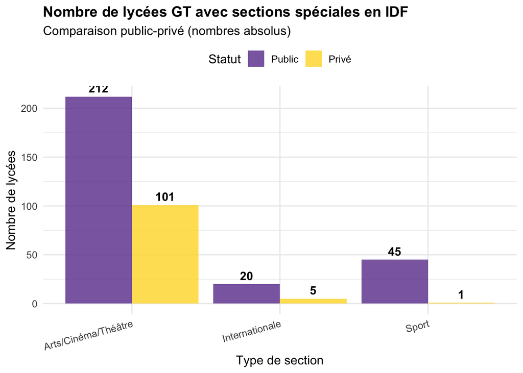

```r
#pas ouf
data_graph_nombres <- stats_globales %>%
  select(statut, n_arts_culture, n_sport, n_internationale) %>%
  pivot_longer(cols = -statut, names_to = "section", values_to = "nombre") %>%
  mutate(
    section = recode(section,
                     n_arts_culture = "Arts/Cinéma/Théâtre",
                     n_sport = "Sport",
                     n_internationale = "Internationale")
  )

# Graphique 1 : Nombres absolus
p4 <- ggplot(data_graph_nombres, aes(x = section, y = nombre, fill = statut)) +
  geom_col(position = "dodge", alpha = 0.8) +
  geom_text(aes(label = nombre), position = position_dodge(width = 0.9),
            vjust = -0.5, size = 4, fontface = "bold") +
  scale_fill_manual(values = c("Public" = "#6A3D9A", "Privé" = "#FFD92F")) +
  labs(
    title = "Nombre de lycées GT avec sections spéciales en IDF",
    subtitle = "Comparaison public-privé (nombres absolus)",
    x = "Type de section",
    y = "Nombre de lycées",
    fill = "Statut"
  ) +
  theme_minimal(base_size = 12) +
  theme(
    legend.position = "top",
    plot.title = element_text(face = "bold", size = 14),
    axis.text.x = element_text(angle = 15, hjust = 1)
  )

print(p4)
```

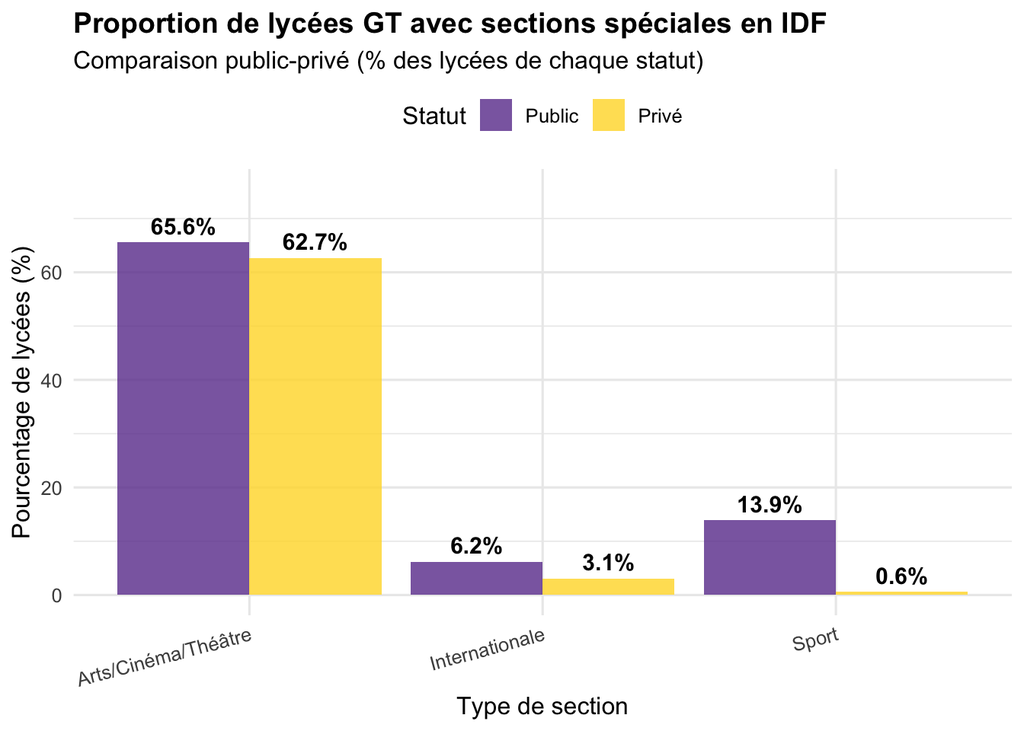

```r
#same mais en %
data_graph_pct <- stats_globales %>%
  select(statut, pct_arts_culture, pct_sport, pct_internationale) %>%
  pivot_longer(cols = -statut, names_to = "section", values_to = "pourcentage") %>%
  mutate(
    section = recode(section,
                     pct_arts_culture = "Arts/Cinéma/Théâtre",
                     pct_sport = "Sport",
                     pct_internationale = "Internationale")
  )

p5 <- ggplot(data_graph_pct, aes(x = section, y = pourcentage, fill = statut)) +
  geom_col(position = "dodge", alpha = 0.8) +
  geom_text(aes(label = paste0(pourcentage, "%")),
            position = position_dodge(width = 0.9),
            vjust = -0.5, size = 4, fontface = "bold") +
  scale_fill_manual(values = c("Public" = "#6A3D9A", "Privé" = "#FFD92F")) +
  labs(
    title = "Proportion de lycées GT avec sections spéciales en IDF",
    subtitle = "Comparaison public-privé (% des lycées de chaque statut)",
    x = "Type de section",
    y = "Pourcentage de lycées (%)",
    fill = "Statut"
  ) +
  ylim(0, max(data_graph_pct$pourcentage) * 1.15) +
  theme_minimal(base_size = 12) +
  theme(
    legend.position = "top",
    plot.title = element_text(face = "bold", size = 14),
    axis.text.x = element_text(angle = 15, hjust = 1)
  )

print(p5)
```

REPARTITION NB DE SECTION PAR LYCEE (voir si ça se cumule)

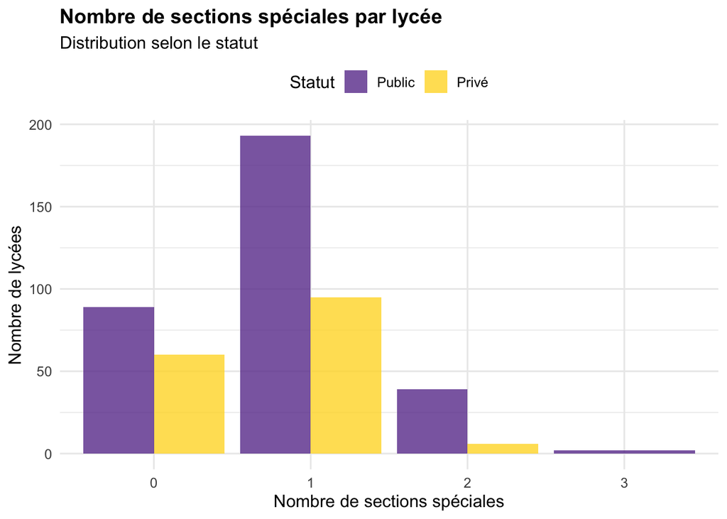

```r
p6 <- ggplot(lycees_filieres, aes(x = factor(nb_sections_speciales), fill = statut)) +
  geom_bar(position = "dodge", alpha = 0.8) +
  scale_fill_manual(values = c("Public" = "#6A3D9A", "Privé" = "#FFD92F")) +
  labs(
    title = "Nombre de sections spéciales par lycée",
    subtitle = "Distribution selon le statut",
    x = "Nombre de sections spéciales",
    y = "Nombre de lycées",
    fill = "Statut"
  ) +
  theme_minimal(base_size = 12) +
  theme(
    legend.position = "top",
    plot.title = element_text(face = "bold", size = 14)
  )

print(p6)
```

LIEN SECTION SPECIALE/IPS

```r
# Comparaison IPS avec/sans sections
comparaison_ips <- lycees_filieres %>%
  group_by(statut, a_section_speciale) %>%
  summarise(
    n = n(),
    ips_moy = round(mean(ips_gt, na.rm = TRUE), 1),
    ips_med = round(median(ips_gt, na.rm = TRUE), 1),
    .groups = "drop"
  )

print(comparaison_ips)
```

```
## # A tibble: 4 × 5
##   statut a_section_speciale     n ips_moy ips_med
##   <fct>  <lgl>              <int>   <dbl>   <dbl>
## 1 Public FALSE                 89    106.    103.
## 2 Public TRUE                 234    114.    114.
## 3 Privé  FALSE                 60    132.    132.
## 4 Privé  TRUE                 101    137.    140.
```

```r
# Test de l'effet des sections sur l'IPS
cat("\nTests de différence d'IPS selon présence de sections spéciales :\n\n")
```

```
##
## Tests de différence d'IPS selon présence de sections spéciales :
```

```r
for(stat in c("Public", "Privé")) {
  data_stat <- lycees_filieres %>% filter(statut == stat)

  if(sum(data_stat$a_section_speciale) > 0 & sum(!data_stat$a_section_speciale) > 0) {
    test <- wilcox.test(ips_gt ~ a_section_speciale, data = data_stat)
    cat(stat, ": p-value =", format.pval(test$p.value, digits = 3))
    if(test$p.value < 0.05) cat(" *")
    cat("\n")
  } else {
    cat(stat, ": pas assez de données pour tester\n")
  }
}
```

```
## Public : p-value = 9.97e-05 *
## Privé : p-value = 0.000851 *
```

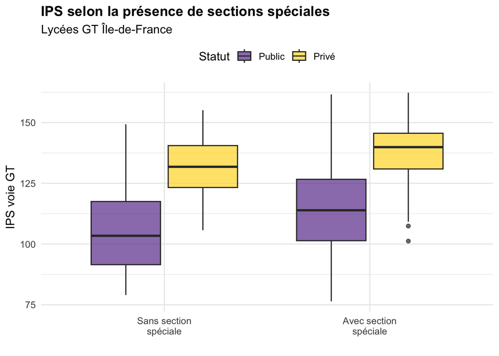

```r
#IPS selon présence de sections
p7 <- ggplot(lycees_filieres, aes(x = a_section_speciale, y = ips_gt, fill = statut)) +
  geom_boxplot(alpha = 0.7) +
  scale_fill_manual(values = c("Public" = "#6A3D9A", "Privé" = "#FFD92F")) +
  scale_x_discrete(labels = c("FALSE" = "Sans section\nspéciale",
                              "TRUE" = "Avec section\nspéciale")) +
  labs(
    title = "IPS selon la présence de sections spéciales",
    subtitle = "Lycées GT Île-de-France",
    x = "",
    y = "IPS voie GT",
    fill = "Statut"
  ) +
  theme_minimal(base_size = 12) +
  theme(
    legend.position = "top",
    plot.title = element_text(face = "bold", size = 14)
  )

print(p7)
```

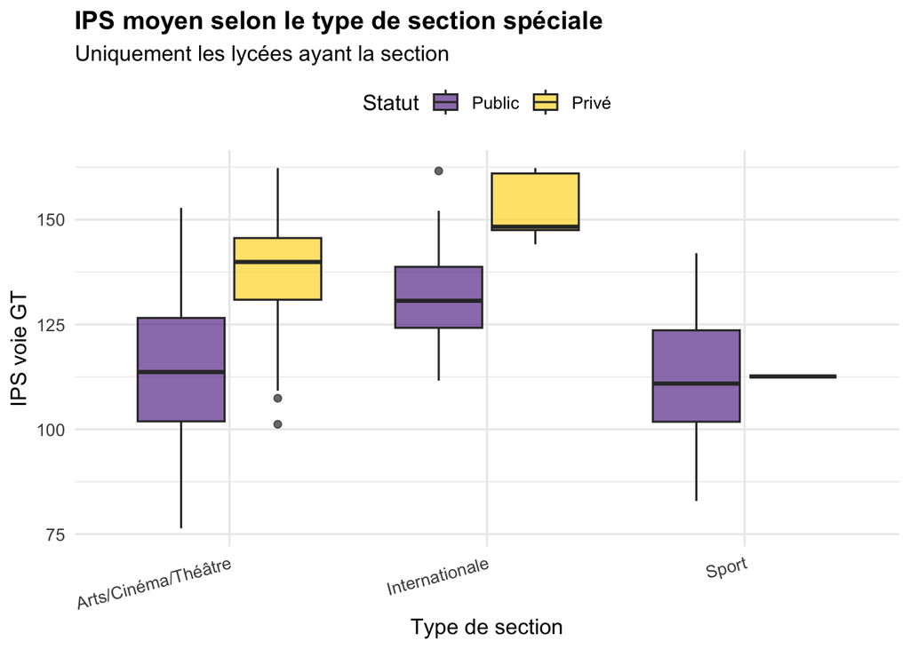

```r
# IPS par type de section
data_ips_sections <- lycees_filieres %>%
  select(statut, ips_gt, arts_culture, sport, internationale) %>%
  pivot_longer(cols = c(arts_culture, sport, internationale),
               names_to = "section", values_to = "presence") %>%
  filter(presence == TRUE) %>%
  mutate(
    section = recode(section,
                     arts_culture = "Arts/Cinéma/Théâtre",
                     sport = "Sport",
                     internationale = "Internationale")
  )

if(nrow(data_ips_sections) > 0) {
  p8 <- ggplot(data_ips_sections, aes(x = section, y = ips_gt, fill = statut)) +
    geom_boxplot(alpha = 0.7) +
    scale_fill_manual(values = c("Public" = "#6A3D9A", "Privé" = "#FFD92F")) +
    labs(
      title = "IPS moyen selon le type de section spéciale",
      subtitle = "Uniquement les lycées ayant la section",
      x = "Type de section",
      y = "IPS voie GT",
      fill = "Statut"
    ) +
    theme_minimal(base_size = 12) +
    theme(
      legend.position = "top",
      plot.title = element_text(face = "bold", size = 14),
      axis.text.x = element_text(angle = 15, hjust = 1)
    )

  print(p8)
}
```

Intéressons-nous désormais aux établissements qui possèdent au moins une section spéciale. Les sections artistiques suivent la même tendance que les lycées de manière globale, soit un IPS plus élevé et une distribution plus resserrée pour l’enseignement privé.L’IPS moyen, de manière global, est légèrement plus élevé que pour les lycées sans section spéciale, mais cet écart reste tout de même assez peu prononcé. Cependant, le fait de posséder une section internationale influence significativement le niveau de l’IPS moyen. En effet, les lycées publics possédant une telle section voient leur IPS moyen distribué entre 125 et 140, et sa distribution plus resserrée bien qu’encore homogène ; tandis que les lycées privés ont un IPS compris entre 150 et 165 (quand les IPS moyens sans section spéciale sont compris entre 90 et 120 pour le public et entre 125 et 140 pour le privé). On constate même un élitisme des sections internationales privées puisque l’IPS médian s’élève à 150, fourchette basse de la catégorie.

SYNTHESE

```r
for(i in 1:nrow(stats_globales)) {
  if(stats_globales$statut[i] == "Public") {
    pub_idx <- i
  } else {
    priv_idx <- i
  }
}

cat("Arts/Cinéma/Théâtre :\n")
```

```
## Arts/Cinéma/Théâtre :
```

```r
cat("Public:", stats_globales$n_arts_culture[pub_idx],
    "| Privé:", stats_globales$n_arts_culture[priv_idx])
```

```
## Public: 212 | Privé: 101
```

```r
if(test_arts$p.value < 0.05) cat("Différence significative")
cat("\n\n")
```

```r
cat("Sport :\n")
```

```
## Sport :
```

```r
cat(" Public:", stats_globales$n_sport[pub_idx],
    "| Privé:", stats_globales$n_sport[priv_idx])
```

```
##  Public: 45 | Privé: 1
```

```r
if(test_sport$p.value < 0.05) cat("Différence significative")
```

```
## Différence significative
```

```r
cat("\n\n")
```

```r
cat("Internationale :\n")
```

```
## Internationale :
```

```r
cat(" Public:", stats_globales$n_internationale[pub_idx],
    "| Privé:", stats_globales$n_internationale[priv_idx])
```

```
##  Public: 20 | Privé: 5
```

```r
if(test_inter$p.value < 0.05) cat("Différence significative")
cat("\n\n")
```

```r
cat("DIFFÉRENCES DE RÉPARTITION (%) :\n\n")
```

```
## DIFFÉRENCES DE RÉPARTITION (%) :
```

```r
cat(" Le secteur privé a proportionnellement :\n")
```

```
##  Le secteur privé a proportionnellement :
```

```r
if(stats_globales$pct_arts_culture[priv_idx] > stats_globales$pct_arts_culture[pub_idx]) {
  cat("    • PLUS de sections Arts/Cinéma/Théâtre (+",
      round(stats_globales$pct_arts_culture[priv_idx] - stats_globales$pct_arts_culture[pub_idx], 1),
      " points)\n")
} else {
  cat("    • MOINS de sections Arts/Cinéma/Théâtre (",
      round(stats_globales$pct_arts_culture[priv_idx] - stats_globales$pct_arts_culture[pub_idx], 1),
      " points)\n")
}
```

```
##     • MOINS de sections Arts/Cinéma/Théâtre ( -2.9  points)
```

```r
if(stats_globales$pct_sport[priv_idx] > stats_globales$pct_sport[pub_idx]) {
  cat("    • PLUS de sections Sport (+",
      round(stats_globales$pct_sport[priv_idx] - stats_globales$pct_sport[pub_idx], 1),
      " points)\n")
} else {
  cat("    • MOINS de sections Sport (",
      round(stats_globales$pct_sport[priv_idx] - stats_globales$pct_sport[pub_idx], 1),
      " points)\n")
}
```

```
##     • MOINS de sections Sport ( -13.3  points)
```

```r
if(stats_globales$pct_internationale[priv_idx] > stats_globales$pct_internationale[pub_idx]) {
  cat("    • PLUS de sections Internationale (+",
      round(stats_globales$pct_internationale[priv_idx] - stats_globales$pct_internationale[pub_idx], 1),
      " points)\n")
} else {
  cat("    • MOINS de sections Internationale (",
      round(stats_globales$pct_internationale[priv_idx] - stats_globales$pct_internationale[pub_idx], 1),
      " points)\n")
}
```

```
##     • MOINS de sections Internationale ( -3.1  points)
```